# Arbeidskrav 3

## 1.

I filen ddf_concepts.csv inneholder det en oversikt over alle datasettene som finnes i gapminderen. En kan der gå inn å se etter datasett som kan være interessante, slik at en da slipper å gå gjennom alle filene for å se hva det er. Det er 596 observasjoner med 17 variabler i filen.

## 2.

I denne filen får vi en oversikt over hvordan befolkningen i ulike land har det. De har rangert hvilken inntektsgruppe befolkningen er i og hvilken religion som er hovedreligionen i landet. De har også sett på om landet har kystlinje eller ikke. Det er også to forskjellige måter å bestemme hvilken verdensregion landene tilhører. Den ene variablene har brukt fire regioner, mens den andre har brukt seks regioner. Det er 273 observasjoner med 21 variabler i filen.

## 3.

I filen er det 8 observasjoner med 4 variabler. Den gir en oversikt over hvilke land som er i variabelen. Et eksempel er “un_oceania_exc_australia_and_new_zealand” som betyr Oceanica uten Australia og New Zealand.

## 4.

```r
library(readr)
g_c <- read_csv("Data/ddf--gapminder--systema_globalis-master/ddf--entities--geo--country.csv")
print(g_c)
```

```
## # A tibble: 273 x 21
##    country g77_and_oecd_co… income_3groups income_groups `is--country`
##    <chr>   <chr>            <chr>          <chr>         <lgl>
##  1 abkh    others           <NA>           <NA>          TRUE
##  2 abw     others           high_income    high_income   TRUE
##  3 afg     g77              low_income     low_income    TRUE
##  4 ago     g77              middle_income  lower_middle… TRUE
##  5 aia     others           <NA>           <NA>          TRUE
##  6 akr_a_… others           <NA>           <NA>          TRUE
##  7 ala     others           <NA>           <NA>          TRUE
##  8 alb     others           middle_income  upper_middle… TRUE
##  9 and     others           high_income    high_income   TRUE
## 10 ant     others           <NA>           <NA>          TRUE
## # … with 263 more rows, and 16 more variables: iso3166_1_alpha2 <chr>,
## #   iso3166_1_alpha3 <chr>, iso3166_1_numeric <dbl>, iso3166_2 <chr>,
## #   landlocked <chr>, latitude <dbl>, longitude <dbl>,
## #   main_religion_2008 <chr>, name <chr>, un_sdg_ldc <chr>,
## #   un_sdg_region <chr>, un_state <lgl>, unicef_region <chr>,
## #   unicode_region_subtag <chr>, world_4region <chr>, world_6region <chr>
```

```r
g_c <- g_c %>%
  mutate(continent = case_when(
    world_4region == "asia" & un_sdg_region %in% c("un_australia_and_new_zealand", "un_oceania_exc_australia_and_new_zealand") ~ "Oceania",
    world_4region ==  "asia" & !(un_sdg_region %in% c("un_australia_and_new_zealand", "un_oceania_exc_australia_and_new_zealand")) ~ "Asia",
    world_4region == "americas" ~ "Americas",
    world_4region == "africa" ~ "Africa",
    world_4region ==  "europe" ~ "Europe")
  ) %>%
 filter(!is.na(iso3166_1_alpha3))
```

```r
view(g_c)
```

## 5.

```r
length(g_c$name)
```

```
## [1] 247
```

Det er 247 land igjen etter oppgave 4.

## 6.

```r
g_c %>%
    count(continent)
```

| continent | n |
| --- | --- |
| Africa | 59 |
| Americas | 55 |
| Asia | 47 |
| Europe | 58 |
| Oceania | 28 |

Fordelingen av land per kontinent kan vi se i tabellen.

## 7.

```r
lifeExp <-read_csv(paste(
  "Data/",
  "ddf--gapminder--systema_globalis-master/",
  "countries-etc-datapoints/",
  "ddf--datapoints--life_expectancy_years--by--geo--time.csv",
  sep=""
  ),
  col_types =cols(time =col_date(format = "%Y")))

lifeExp <- lifeExp%>%
rename(year = time)

length(unique(lifeExp$geo))
```

```
## [1] 189
```

Det er nå 189 land igjen med informasjon om forventet levetid.

## 8.

```r
g_c <- g_c%>%
    select(country, name, iso3166_1_alpha3, main_religion_2008,
           un_sdg_region, world_4region, continent, world_6region) %>%
    left_join(lifeExp, by =c("country" = "geo")) %>%
    filter(!(is.na(year)& is.na(life_expectancy_years))) %>%
    filter(year<"2020-01-01")
```

## 9.

```r
g_c_min <- g_c %>%
  group_by(country) %>%
  summarise(min_year = min(year))
table(g_c_min$min_year)
```

```
##
## 1800-01-01 1970-01-01
##        186          3
```

Vi ser ved å bruke table-funksjonen får vi opp to forskjellige årstall og antall observasjoner. I 1800 er det 186 observasjoner og i 1970 er det 3 observasjoner. Siden vi forventer at levealder har økt siden 1800, er det mer relevant å se på 1970.

```r
g_c_min %>%
    filter(min_year == "1970-01-01")
```

| country | min_year |
| --- | --- |
| and | 1970-01-01 |
| dma | 1970-01-01 |
| mhl | 1970-01-01 |

```r
g_c_min <- g_c_min %>%
  left_join(g_c,
            by = "country") %>%
  filter(min_year == "1970-01-01")

attach(g_c_min)
tibble(country = unique(name))
```

| country |
| --- |
| Andorra |
| Dominica |
| Marshall Islands |

## 10.

```r
pop <- read_csv("Data/ddf--gapminder--systema_globalis-master/countries-etc-datapoints/ddf--datapoints--population_total--by--geo--time.csv",
col_types = cols(time = col_date(format = "%Y")))
```

```r
g_c <- g_c%>%
    left_join(pop, by =c("country" = "geo", "year" = "time"))
```

## 11.

```r
u_pop <- read_csv("Data/ddf--gapminder--systema_globalis-master/countries-etc-datapoints/ddf--datapoints--urban_population--by--geo--time.csv",
    col_types = cols(time = col_date(format = "%Y")))
```

```r
g_c <- g_c %>%
  left_join(u_pop, by = c("country" = "geo", "year" = "time"))
```

## 12.

```r
gdp_pc <- read_csv("Data/ddf--gapminder--systema_globalis-master/countries-etc-datapoints/ddf--datapoints--gdppercapita_us_inflation_adjusted--by--geo--time.csv",
    col_types = cols(time = col_date(format = "%Y")))
```

```r
g_c <- g_c %>%
  left_join(gdp_pc, by = c("country" = "geo", "year" = "time"))
```

## 13.

```r
g_c <- g_c %>%
  rename("gdpPercap" = "gdppercapita_us_inflation_adjusted") %>%
  rename("lifeExp" = "life_expectancy_years") %>%
  rename("pop" = "population_total")
```

```r
resy <- paste(seq(1962, 2017, by = 5), "01-01", sep = "-") %>%
  parse_date(format = "%Y-%m-%d")

gapminder1 <- g_c %>%
  filter(year %in% resy) %>%
  select(name, continent, year, lifeExp, pop, gdpPercap) %>%
  rename("country" = "name")

dim(gapminder1)
```

```
## [1] 2262    6
```

Deretter opprettet vi datasettet “gapminder1” der vi først rangerte variabelen “year”, for så å ta med de andre variablene “country, continent, year, lifeExp, pop, gdpPercap”.

## 14.

```r
my_gapminder_1962 <- gapminder1 %>%
  group_by(country) %>%
  filter(year == "1962-01-01") %>%
  filter(!is.na(gdpPercap))

length(unique(my_gapminder_1962$country))
```

```
## [1] 90
```

Vi ser her at det nå er 90 land igjen etter at vi fjernet de som manglet data om gdpPercap. Under har vi fått opp en tabell som viser hvordan fordelingen av land per kontinent er. Det er flest land fra Afrika og minst land fra Oceania.

```r
my_gapminder_1962 %>%
  distinct(country, continent) %>%
  group_by(continent) %>%
  count() %>%
  kable()
```

| continent | n |
| --- | --- |
| Africa | 30 |
| Americas | 25 |
| Asia | 17 |
| Europe | 15 |
| Oceania | 3 |

```r
my_gapminder_venezuela <- gapminder1 %>%
  group_by(country) %>%
  filter(country == "Venezuela") %>%
  filter(!is.na(gdpPercap))

  my_gapminder_venezuela
```

| country | continent | year | lifeExp | pop | gdpPercap |
| --- | --- | --- | --- | --- | --- |
| Venezuela | Americas | 1962-01-01 | 61.87 | 8742780 | 12992.83 |
| Venezuela | Americas | 1967-01-01 | 64.78 | 10359741 | 13766.11 |
| Venezuela | Americas | 1972-01-01 | 66.31 | 12097696 | 14107.19 |
| Venezuela | Americas | 1977-01-01 | 68.47 | 13964377 | 15739.38 |
| Venezuela | Americas | 1982-01-01 | 69.97 | 16017570 | 13197.39 |
| Venezuela | Americas | 1987-01-01 | 71.62 | 18232733 | 12511.19 |
| Venezuela | Americas | 1992-01-01 | 72.57 | 20557694 | 13302.59 |
| Venezuela | Americas | 1997-01-01 | 73.71 | 22837743 | 12939.58 |
| Venezuela | Americas | 2002-01-01 | 74.04 | 25100407 | 10848.82 |
| Venezuela | Americas | 2007-01-01 | 75.00 | 27247601 | 14374.37 |

[output cut: 1 more lines]

## 15.

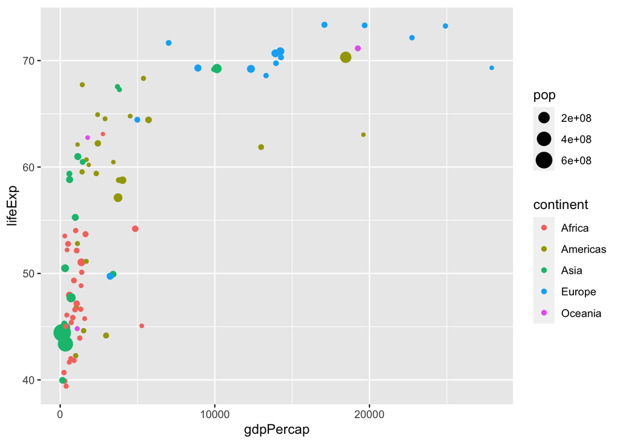

```r
my_gapminder_1962 %>%
  ggplot(my_gampinder_1962, mapping = aes(x = gdpPercap, y = lifeExp, size = pop, colour = continent)) +
  geom_point()
```

```r
my_gapminder_1987 <- gapminder1 %>%
  group_by(country) %>%
  filter(year == "1987-01-01") %>%
  filter(!is.na(gdpPercap))
```

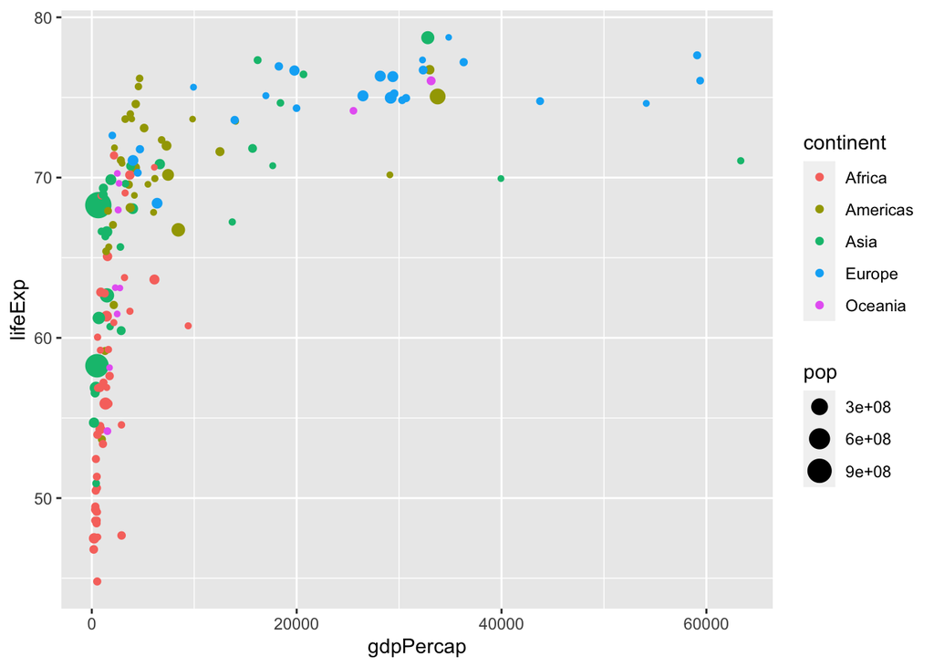

```r
my_gapminder_1987 %>%
  ggplot(my_gampinder_1987, mapping = aes(x = gdpPercap, y = lifeExp, size = pop, colour = continent)) +
  geom_point()
```

```r
my_gapminder_2017 <- gapminder1 %>%
  group_by(country) %>%
  filter(year == "2017-01-01") %>%
  filter(!is.na(gdpPercap))
```

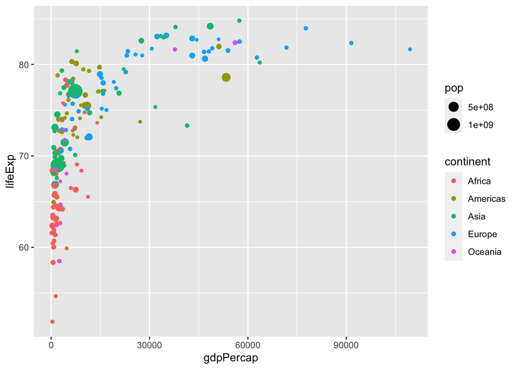

```r
my_gapminder_2017 %>%
  ggplot(my_gampinder_2017, mapping = aes(x = gdpPercap, y = lifeExp, size = pop, colour = continent)) +
  geom_point()
```

## 16.

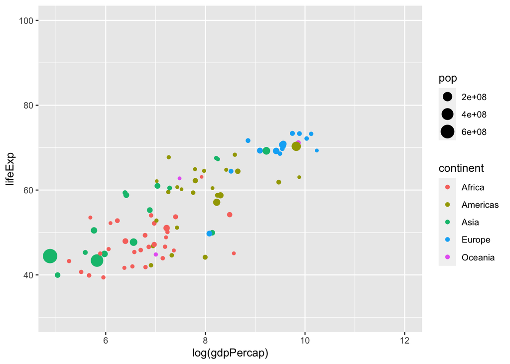

```r
my_gapminder_1962 %>%
  ggplot(my_gampinder_1962, mapping = aes(x = log(gdpPercap), y = lifeExp, size = pop, colour = continent)) +
  geom_point()+
  coord_cartesian(xlim = c(5, 12), ylim = c(30, 100))
```

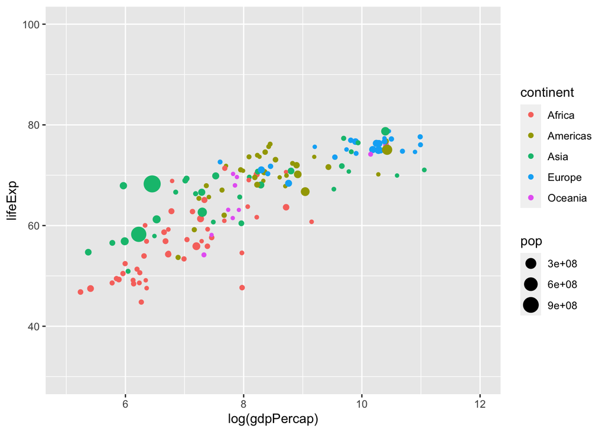

```r
my_gapminder_1987 %>%
  ggplot(my_gampinder_1987, mapping = aes(x = log(gdpPercap), y = lifeExp, size = pop, colour = continent)) +
  geom_point()+
  coord_cartesian(xlim = c(5, 12), ylim = c(30, 100))
```

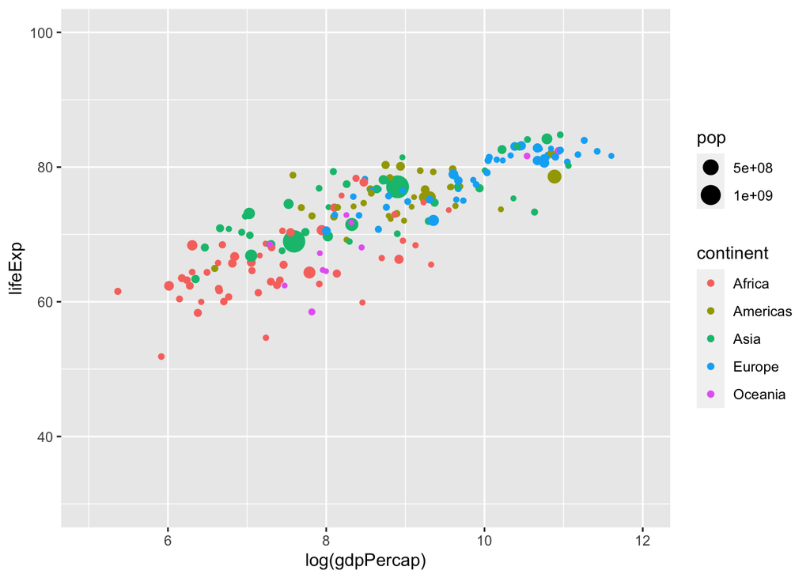

```r
my_gapminder_2017 %>%
  ggplot(my_gampinder_2017, mapping = aes(x = log(gdpPercap), y = lifeExp, size = pop, colour = continent)) +
  geom_point()+
  coord_cartesian(xlim = c(5, 12), ylim = c(30, 100))
```

## 17.

Vi kan se at den generelle forventede levealderen har steget de siste 55 årene. I 1962 var det mange land fra Afrika, Amerikas og Asia som hadde lav gdpPercap og lav forventet levealder, mens over årene har disse landene og kontinentene fått en høyere levealder og en høyere gdpPercap.